# 카테고리별 소분류 연관분석

## 연관분석 시각화 -1

[output not shown]

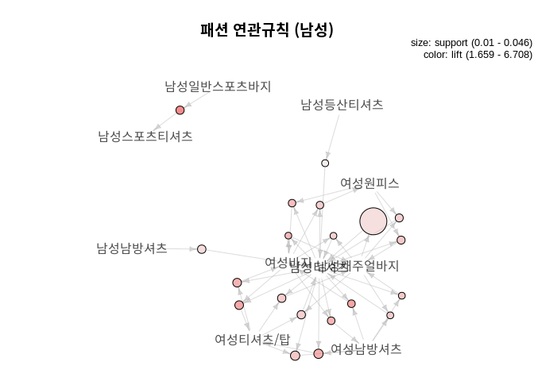

```r
library(arulesViz)
plot(C5_1, method = "graph",
     control = list(type = 'items'),
     main = '패션 연관규칙 (남성)',
     vertex.label.cex = 0.7,
     edge.arrow.size = 0.3)
```

## 연관분석 시각화 -2

[output not shown]

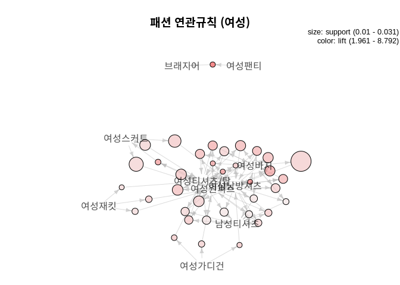

```r
plot(C5_2, method = "graph",
     control = list(type = 'items'),
     main = '패션 연관규칙 (여성)',
     vertex.label.cex = 0.7,
     edge.arrow.size = 0.3)
```

## 인사이트

1. 겉옷을 산 고객들은 티셔츠, 원피스 등 상의를 같이 사는 패턴을 보임
- 겉옷에 걸맞은 상의를 사는 것으로 추측됨
- 겉옷에 매칭할 수 있는 상의나 하의 상품을 추천한다.
2. 상의를 산 고객들은 하의를 사는 패턴을 보임
- 상의에 걸맞는 상의를 사는 것으로 추측됨
- 상의에 매칭할 수 있는 하의 상품을 추천한다.
3. 스포츠 의류를 산 고객들은 또다른 스포츠 의류를 구매하는 패턴을 보임
- 스포츠 의류의 경우 특히 브랜드 선호도가 큰 영향을 미치므로 선택한 제품의 브랜드를 중심으로 아웃도어 의류 상품을 추천한다.

# 6. 뷰티 카테고리 소분류 연관분석

```r
# 데이터 전처리
library(dplyr)

a <- train_order
a <- inner_join(a, df_product, by=c('PD_C', 'CN_our'))
a <- inner_join(a, df_master, by=c('CLAC_C', 'CN_our'))

df <- a %>%
    filter(CN_our == 'C6')

clac3 <- df[c('CLAC3_NM', 'CLNT_ID')]

# 소분류(CLAC_3) 품목 개수 확인
length(unique(clac3$CLAC3_NM))
```

```
## [1] 79
```

```r
# 고객 id별로 구매 항목 모으기
clac3_list <- split(clac3$CLAC3_NM, clac3$CLNT_ID)

# 중복 제거하고 transaction으로 변환
library(arules)
clac3_list <- sapply(clac3_list, unique)
clac3_list <- as(clac3_list, 'transactions')

# 연관규칙 생성 - 지지도 0.004 이상, 신뢰도 0.3이상
clac3_rule <- apriori(clac3_list, parameter = list(support = 0.004, confidence = 0.3, minlen = 2))
```

```
## Apriori
##
## Parameter specification:
##  confidence minval smax arem  aval originalSupport maxtime support minlen
##         0.3    0.1    1 none FALSE            TRUE       5   0.004      2
##  maxlen target   ext
##      10  rules FALSE
##
## Algorithmic control:
##  filter tree heap memopt load sort verbose
##     0.1 TRUE TRUE  FALSE TRUE    2    TRUE
##
## Absolute minimum support count: 656
##
## set item appearances ...[0 item(s)] done [0.00s].
## set transactions ...[79 item(s), 164207 transaction(s)] done [0.02s].
## sorting and recoding items ... [58 item(s)] done [0.00s].
## creating transaction tree ... done [0.05s].
## checking subsets of size 1 2 3 4 done [0.00s].
## writing ... [46 rule(s)] done [0.00s].
## creating S4 object  ... done [0.01s].
```

```r
summary(clac3_rule)
```

```
## set of 46 rules
##
## rule length distribution (lhs + rhs):sizes
##  2  3
##  7 39
##
##    Min. 1st Qu.  Median    Mean 3rd Qu.    Max.
##   2.000   3.000   3.000   2.848   3.000   3.000
##
## summary of quality measures:
##     support           confidence          lift           count
##  Min.   :0.004001   Min.   :0.3001   Min.   :1.666   Min.   : 657.0
##  1st Qu.:0.004415   1st Qu.:0.3159   1st Qu.:2.012   1st Qu.: 725.0
##  Median :0.005064   Median :0.3491   Median :2.390   Median : 831.5
##  Mean   :0.006321   Mean   :0.3725   Mean   :2.459   Mean   :1037.9
##  3rd Qu.:0.006474   3rd Qu.:0.4159   3rd Qu.:2.847   3rd Qu.:1063.0
##  Max.   :0.017825   Max.   :0.5735   Max.   :3.747   Max.   :2927.0
##
## mining info:
##        data ntransactions support confidence
##  clac3_list        164207   0.004        0.3
```

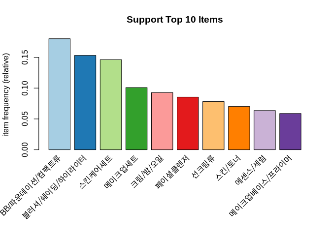

```r
# 지지도 상위 10개 막대그래프
library(RColorBrewer)
itemFrequencyPlot(clac3_list,
                  topN = 10,
                  main = 'Support Top 10 Items',
                  col = brewer.pal(12,'Paired'))
```

```r
# 향상도 높은순으로 내림차순하기
(sort(clac3_rule, by = 'lift'))
```

```
## set of 46 rules
```

```r
# 연관규칙 2그룹으로 분리하기
C6_1 <- clac3_rule[c(1:24,31:33,36,39,42:46), ]   # 메이크업 제품
C6_2 <- clac3_rule[c(25:30,34,35,37,38,40,41), ]  # 스킨케어 제품
```

## 연관분석 시각화 -1

[output not shown]

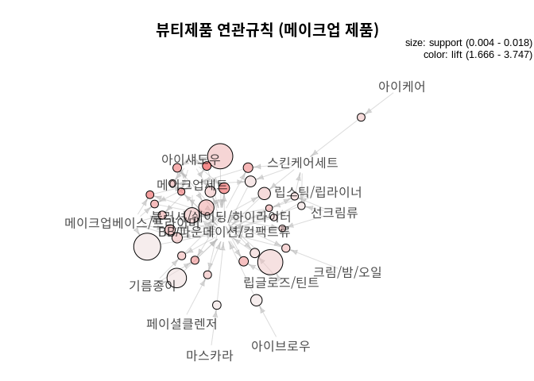

```r
library(arulesViz)
plot(C6_1, method = "graph",
     control = list(type = 'items'),
     main = '뷰티제품 연관규칙 (메이크업 제품)',
     vertex.label.cex = 0.7,
     edge.arrow.size = 0.3)
```

## 연관분석 시각화 -2

[output not shown]

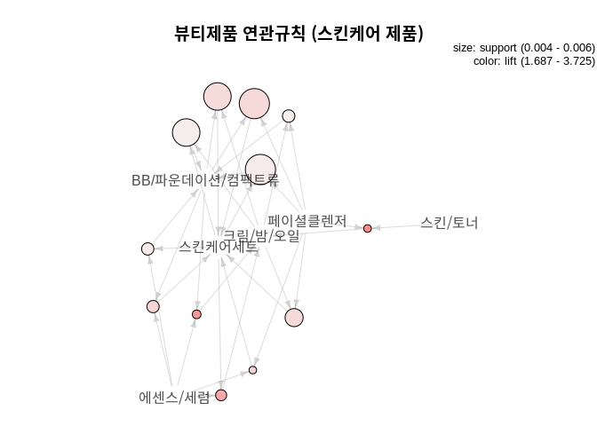

```r
plot(C6_2, method = "graph",
     control = list(type = 'items'),
     main = '뷰티제품 연관규칙 (스킨케어 제품)',
     vertex.label.cex = 0.7,
     edge.arrow.size = 0.3)
```

## 인사이트

1. 스킨케어제품(스킨, 토너, 클렌져, 오일, 크림 등)을 동시에 구매하는 패턴을 보임
2. 아이섀도우를 사는 사람은 블러셔, 쉐이딩과 같은 다른 포인트 메이크업 제품도 함께 구매하는 패턴을 보임
- 색조 메이크업마다 그에 어울리는 제품을 같이 구매하는 것으로 추측됨
3. 파운데이션 등 베이스 메이크업 제품을 살 때 크림/밤/오일을 같이 구매하는 패턴을 보임
- 파운데이션 제품의 농도에 따라 그에 걸맞은 크림을 살 것으로 추측됨
4. 파운데이션 등 베이스 메이크업 제품을 살 때 메이크업베이스/프라이머를 같이 구매하는 패턴을 보임
- 파운데이션에 걸맞은 베이스 제품을 같이 사는 것으로 추측됨

** 활용방안 : 연관성이 높은 제품들을 제품 상세페이지에 함께 추천하여 관심을 끈다.

# 7. 유아용품 카테고리 소분류 연관분석

```r
# 데이터 전처리
library(dplyr)

a <- train_order
a <- inner_join(a, df_product, by=c('PD_C', 'CN_our'))
a <- inner_join(a, df_master, by=c('CLAC_C', 'CN_our'))

df <- a %>%
    filter(CN_our == 'C7')

clac3 <- df[c('CLAC3_NM', 'CLNT_ID')]

# 소분류(CLAC_3) 품목 개수 확인
length(unique(clac3$CLAC3_NM))
```

```
## [1] 95
```

```r
# 고객 id별로 구매 항목 모으기
clac3_list <- split(clac3$CLAC3_NM, clac3$CLNT_ID)

# 중복 제거하고 transaction으로 변환
library(arules)
clac3_list <- sapply(clac3_list, unique)
clac3_list <- as(clac3_list, 'transactions')

# 연관규칙 생성 - 지지도 0.01 이상, 신뢰도 0.3이상
clac3_rule <- apriori(clac3_list, parameter = list(support = 0.01, confidence = 0.3, minlen = 2))
```

```
## Apriori
##
## Parameter specification:
##  confidence minval smax arem  aval originalSupport maxtime support minlen
##         0.3    0.1    1 none FALSE            TRUE       5    0.01      2
##  maxlen target   ext
##      10  rules FALSE
##
## Algorithmic control:
##  filter tree heap memopt load sort verbose
##     0.1 TRUE TRUE  FALSE TRUE    2    TRUE
##
## Absolute minimum support count: 1018
##
## set item appearances ...[0 item(s)] done [0.00s].
## set transactions ...[95 item(s), 101818 transaction(s)] done [0.01s].
## sorting and recoding items ... [48 item(s)] done [0.00s].
## creating transaction tree ... done [0.03s].
## checking subsets of size 1 2 3 4 done [0.00s].
## writing ... [54 rule(s)] done [0.00s].
## creating S4 object  ... done [0.01s].
```

```r
summary(clac3_rule)
```

```
## set of 54 rules
##
## rule length distribution (lhs + rhs):sizes
##  2  3
## 24 30
##
##    Min. 1st Qu.  Median    Mean 3rd Qu.    Max.
##   2.000   2.000   3.000   2.556   3.000   3.000
##
## summary of quality measures:
##     support          confidence          lift           count
##  Min.   :0.01003   Min.   :0.3019   Min.   :1.858   Min.   :1021
##  1st Qu.:0.01150   1st Qu.:0.3540   1st Qu.:2.909   1st Qu.:1171
##  Median :0.01448   Median :0.4549   Median :3.446   Median :1474
##  Mean   :0.01884   Mean   :0.4551   Mean   :3.445   Mean   :1918
##  3rd Qu.:0.02112   3rd Qu.:0.5377   3rd Qu.:3.917   3rd Qu.:2151
##  Max.   :0.05951   Max.   :0.7096   Max.   :6.694   Max.   :6059
##
## mining info:
##        data ntransactions support confidence
##  clac3_list        101818    0.01        0.3
```

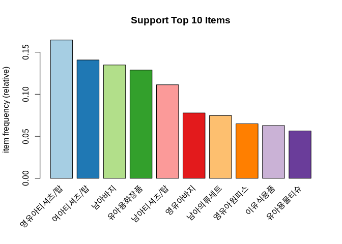

```r
# 지지도 상위 10개 막대그래프
library(RColorBrewer)
itemFrequencyPlot(clac3_list,
                  topN = 10,
                  main = 'Support Top 10 Items',
                  col = brewer.pal(12,'Paired'))
```

```r
# 향상도 높은순으로 내림차순하기
inspect(sort(clac3_rule, by = 'lift'))
```

```
##      lhs                                rhs               support    confidence
## [1]  {여아티셔츠/탑,영유아원피스}    => {영유아바지}      0.01389735 0.5204119
## [2]  {여아티셔츠/탑,영유아바지}      => {영유아원피스}    0.01389735 0.3583186
## [3]  {영유아바지,영유아원피스}       => {여아티셔츠/탑}   0.01389735 0.7096289
## [4]  {남아청바지,영유아티셔츠/탑}    => {남아바지}        0.01041073 0.6559406
## [5]  {영유아청바지}                  => {여아티셔츠/탑}   0.01165806 0.6320554
## [6]  {여아남방셔츠}                  => {여아티셔츠/탑}   0.01290538 0.6134454
## [7]  {남아바지,영유아바지}           => {여아티셔츠/탑}   0.01088216 0.5743909
## [8]  {남아바지,여아티셔츠/탑}        => {영유아바지}      0.01088216 0.3172058
## [9]  {여아티셔츠/탑,영유아티셔츠/탑} => {영유아바지}      0.01308217 0.3163144
## [10] {남아바지,남아의류세트}         => {남아티셔츠/탑}   0.01046966 0.4499789
## [11] {남아의류세트,남아티셔츠/탑}    => {남아바지}        0.01046966 0.5405680
## [12] {남아의류세트,영유아티셔츠/탑}  => {남아바지}        0.01352413 0.5383112
## [13] {남아티셔츠/탑,영유아티셔츠/탑} => {남아바지}        0.02348308 0.5359785
## [14] {여아바지}                      => {여아티셔츠/탑}   0.02163665 0.5515774
```

[output cut: 95 more lines]

```r
# 연관규칙 2그룹으로 분리하기
C7_1 <- clac3_rule[c(8:11,14,15,20:32,39,43:50), ]       # 남아 제품
C7_2 <- clac3_rule[c(1:7,12,13,16:19,33:38,40:42,51:54), ]  # 여아 제품
```

## 연관분석 시각화 -1

[output not shown]

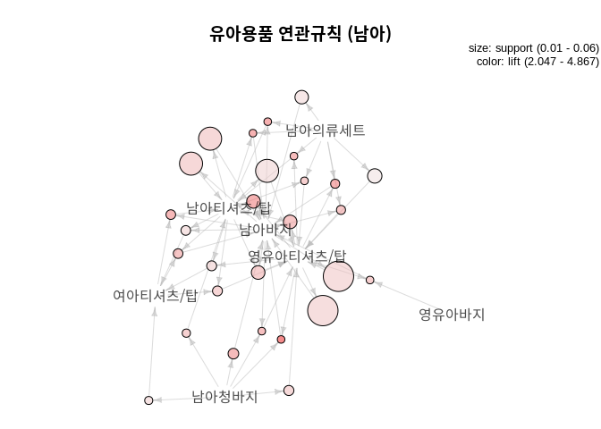

```r
library(arulesViz)
plot(C7_1, method = "graph",
     control = list(type = 'items'),
     main = '유아용품 연관규칙 (남아)',
     vertex.label.cex = 0.7,
     edge.arrow.size = 0.3)
```

## 연관분석 시각화 -2

[output not shown]

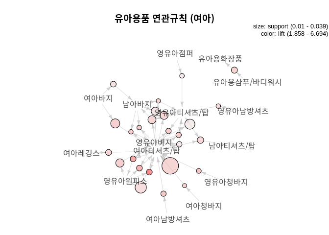

```r
plot(C7_2, method = "graph",
     control = list(type = 'items'),
     main = '유아용품 연관규칙 (여아)',
     vertex.label.cex = 0.7,
     edge.arrow.size = 0.3)
```

## 인사이트

1. 유아용품에서 주로 의류를 사는 고객들이 대다수였으며, 상하의를 함께 사는 패턴을 보임
2. 유아용 목욕용품, 유아용 화장품을 같이 구매하는 패턴을 보임
3. 유아용품 내에서 지지도가 높았던 유아용 화장품은 아토팜 브랜드가 매출이 가장 높고, 판매량도 가장 많다.

** 활용방안 : 연관성이 높은 제품들을 제품 상세페이지에 함께 추천하여 관심을 끈다.

# 8. 취미용품 카테고리 소분류 연관분석

```r
# 데이터 전처리
library(dplyr)

a <- train_order
a <- inner_join(a, df_product, by=c('PD_C', 'CN_our'))
a <- inner_join(a, df_master, by=c('CLAC_C', 'CN_our'))

df <- a %>%
    filter(CN_our == 'C8')

clac3 <- df[c('CLAC3_NM', 'CLNT_ID')]

# 소분류(CLAC_3) 품목 개수 확인
length(unique(clac3$CLAC3_NM))
```

```
## [1] 24
```

```r
# 고객 id별로 구매 항목 모으기
clac3_list <- split(clac3$CLAC3_NM, clac3$CLNT_ID)

# 중복 제거하고 transaction으로 변환
library(arules)
clac3_list <- sapply(clac3_list, unique)
clac3_list <- as(clac3_list, 'transactions')

# 연관규칙 생성 - 지지도 0.01 이상, 신뢰도 0.3이상
clac3_rule <- apriori(clac3_list, parameter = list(support = 0.01, confidence = 0.3, minlen = 2))
```

```
## Apriori
##
## Parameter specification:
##  confidence minval smax arem  aval originalSupport maxtime support minlen
##         0.3    0.1    1 none FALSE            TRUE       5    0.01      2
##  maxlen target   ext
##      10  rules FALSE
##
## Algorithmic control:
##  filter tree heap memopt load sort verbose
##     0.1 TRUE TRUE  FALSE TRUE    2    TRUE
##
## Absolute minimum support count: 191
##
## set item appearances ...[0 item(s)] done [0.00s].
## set transactions ...[24 item(s), 19131 transaction(s)] done [0.00s].
## sorting and recoding items ... [16 item(s)] done [0.00s].
## creating transaction tree ... done [0.00s].
## checking subsets of size 1 2 3 done [0.00s].
## writing ... [23 rule(s)] done [0.00s].
## creating S4 object  ... done [0.00s].
```

```r
summary(clac3_rule)
```

```
## set of 23 rules
##
## rule length distribution (lhs + rhs):sizes
##  2  3
## 13 10
##
##    Min. 1st Qu.  Median    Mean 3rd Qu.    Max.
##   2.000   2.000   2.000   2.435   3.000   3.000
##
## summary of quality measures:
##     support          confidence          lift           count
##  Min.   :0.01025   Min.   :0.3041   Min.   :1.050   Min.   : 196.0
##  1st Qu.:0.01166   1st Qu.:0.3399   1st Qu.:1.736   1st Qu.: 223.0
##  Median :0.01558   Median :0.4135   Median :2.305   Median : 298.0
##  Mean   :0.02202   Mean   :0.4330   Mean   :2.270   Mean   : 421.3
##  3rd Qu.:0.02384   3rd Qu.:0.5152   3rd Qu.:2.755   3rd Qu.: 456.0
##  Max.   :0.07213   Max.   :0.6447   Max.   :3.887   Max.   :1380.0
##
## mining info:
##        data ntransactions support confidence
##  clac3_list         19131    0.01        0.3
```

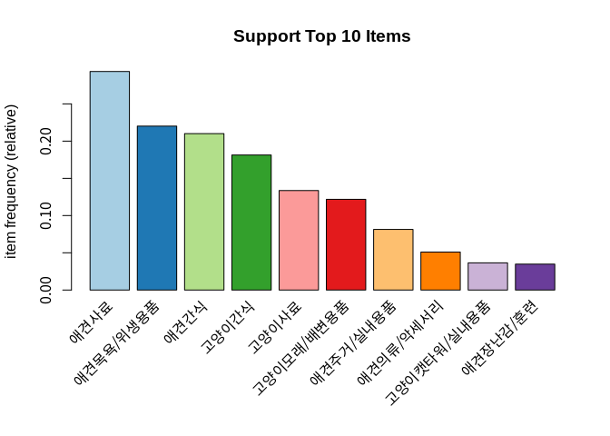

```r
# 지지도 상위 10개 막대그래프
library(RColorBrewer)
itemFrequencyPlot(clac3_list,
                  topN = 10,
                  main = 'Support Top 10 Items',
                  col = brewer.pal(12,'Paired'))
```

```r
# 향상도 높은순으로 내림차순하기
inspect(sort(clac3_rule, by = 'lift'))
```

```
##      lhs                                      rhs                   support
## [1]  {고양이간식,고양이모래/배변용품}      => {고양이사료}          0.01876535
## [2]  {고양이모래/배변용품,고양이사료}      => {고양이간식}          0.01876535
## [3]  {고양이장난감}                        => {고양이간식}          0.01165647
## [4]  {애견간식,애견의류/악세서리}          => {애견목욕/위생용품}   0.01024515
## [5]  {고양이간식,고양이사료}               => {고양이모래/배변용품} 0.01876535
## [6]  {고양이캣타워/실내용품}               => {고양이모래/배변용품} 0.01233600
## [7]  {애견간식,애견주거/실내용품}          => {애견목욕/위생용품}   0.01108149
## [8]  {애견목욕/위생용품,애견의류/악세서리} => {애견간식}            0.01024515
## [9]  {고양이캣타워/실내용품}               => {고양이사료}          0.01238827
## [10] {애견목욕/위생용품,애견주거/실내용품} => {애견간식}            0.01108149
## [11] {고양이캣타워/실내용품}               => {고양이간식}          0.01557681
## [12] {애견목욕/위생용품,애견사료}          => {애견간식}            0.02890596
## [13] {고양이사료}                          => {고양이간식}          0.05514610
## [14] {고양이간식}                          => {고양이사료}          0.05514610
```

[output cut: 33 more lines]

## 연관분석 시각화

[output not shown]

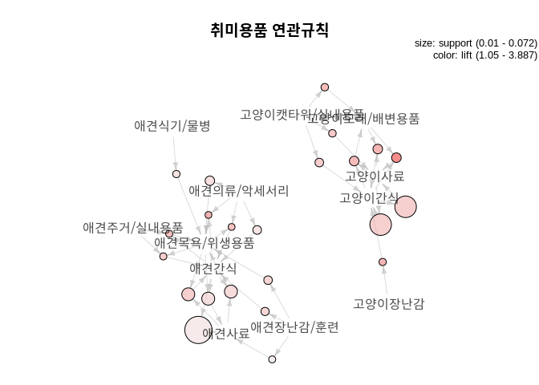

```r
library(arulesViz)
plot(clac3_rule, method = "graph",
     main = '취미용품 연관규칙',
     control = list(type = 'items'),
     vertex.label.cex = 0.7,
     edge.arrow.size = 0.3)
```

## 인사이트

1. 강아지 용품을 사는 사람과 고양이 용품을 사는 고객으로 나뉨
2. 반려인들에게 사료나 간식은 꼭 필요한 상품으로 대부분의 상품과도 높은 연관성을 보임
- 반려동물 용품을 구매하는 고객들에게 공통적으로 인기가 많은 사료와 간식을 추천한다.
- 또한 사료나 간식의 경우, 특정 브랜드의 제품만 구입하는 고객들이 있으므로 상품 선택시 같은 브랜드의 다양한 제품을 함께 추천하여 관심을 끈다.

# 9. 스포츠패션 & 건강식품 소분류 연관분석

- 스포츠패션과 건강기능식품(영양제) 사이에 얼마나 연관성이 있는지 분석한다.

```r
library(dplyr)

# 데이터 전처리
a <- train_order
a <- inner_join(a, df_product, by=c('PD_C', 'CN_our'))
a <- inner_join(a, df_master, by=c('CLAC_C', 'CN_our'))

df <- a %>%
  filter(CN_our == 'C5' & CLAC1_NM == '스포츠패션')
df2 <- a %>%
  filter(CN_our == 'C3' & CLAC1_NM == '건강식품')

df3 <- bind_rows(df, df2)
clac3 <- df3[c('CLAC3_NM', 'CLNT_ID')]

# 소분류(CLAC_3) 품목 개수 확인
length(unique(clac3$CLAC3_NM))
```

```
## [1] 99
```

```r
# 고객 id별로 구매 항목 모으기
clac3_list <- split(clac3$CLAC3_NM, clac3$CLNT_ID)

# 중복 제거하고 transaction으로 변환
library(arules)
clac3_list <- sapply(clac3_list, unique)
clac3_list <- as(clac3_list, 'transactions')

# 연관규칙 생성 - 지지도 0.0001 이상, 신뢰도 0.3이상
clac3_rule <- apriori(clac3_list, parameter = list(support = 0.0001, confidence = 0.3, minlen = 2))
```

```
## Apriori
##
## Parameter specification:
##  confidence minval smax arem  aval originalSupport maxtime support minlen
##         0.3    0.1    1 none FALSE            TRUE       5  0.0001      2
##  maxlen target   ext
##      10  rules FALSE
##
## Algorithmic control:
##  filter tree heap memopt load sort verbose
##     0.1 TRUE TRUE  FALSE TRUE    2    TRUE
##
## Absolute minimum support count: 17
##
## set item appearances ...[0 item(s)] done [0.00s].
## set transactions ...[99 item(s), 176421 transaction(s)] done [0.02s].
## sorting and recoding items ... [96 item(s)] done [0.00s].
## creating transaction tree ... done [0.06s].
## checking subsets of size 1 2 3 4 5 6 done [0.01s].
## writing ... [10086 rule(s)] done [0.00s].
## creating S4 object  ... done [0.02s].
```

```r
clac3_rule2 <- clac3_rule[c(518,618,645,649,719,721,722,819,823,1019,1020,1072,1076,1104,1164,1167,1177,1178,1189,1198,3299,3317,3348,3349,3371,3373,3397,3402,3411,4152,4153,4160), ]

inspect(clac3_rule2)
```

```
##      lhs
## [1]  {남성스포츠티셔츠,자연유래영양제}                              =>
## [2]  {남성일반스포츠바지,채소즙}                                    =>
## [3]  {남성등산티셔츠,칼슘/미네랄}                                   =>
## [4]  {남성런닝/트레이닝화,칼슘/미네랄}                              =>
## [5]  {루테인,유아동스포츠샌들/슬리퍼}                               =>
## [6]  {남성등산티셔츠,루테인}                                        =>
## [7]  {남성일반스포츠바지,루테인}                                    =>
## [8]  {여성스포츠샌들/슬리퍼,오메가3/기타추출오일}                   =>
## [9]  {남성일반스포츠바지,오메가3/기타추출오일}                      =>
## [10] {남성등산티셔츠,종합영양제}                                    =>
## [11] {남성일반스포츠바지,종합영양제}                                =>
## [12] {유아동스포츠티셔츠/탑,일반비타민}                             =>
## [13] {유아동스포츠티셔츠/탑,홍삼액}                                 =>
## [14] {여성등산점퍼/재킷,일반비타민}                                 =>
```

[output cut: 51 more lines]

## 연관분석 시각화

[output not shown]

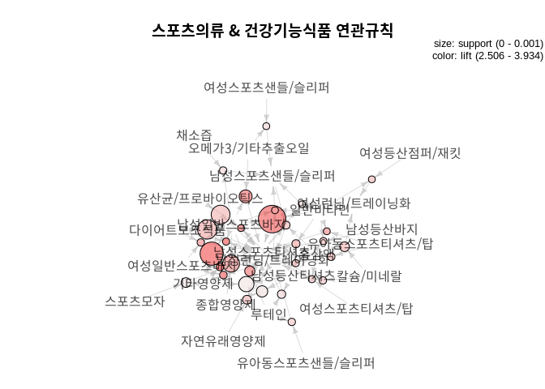

```r
library(arulesViz)
plot(clac3_rule2, method = "graph",
     main = '스포츠의류 & 건강기능식품 연관규칙',
     control = list(type = 'items'),
     vertex.label.cex = 0.7,
     edge.arrow.size = 0.3)
```

## 인사이트

- 스포츠 의류를 사는 고객 중에 건강기능식품을 같이 구매하는 패턴이 보였지만, 구매횟수가 그리 많지 않았다. 이를 활용하여 운동과 건강에 관심이 많은 고객들을 대상으로 건강기능식품에 대한 프로모션을 진행하면 좋을 것 같다.